# Social Norms Meta

# Analysis Treatment-level: All Games

## HP1: Relation between norms and actions

#### *Are norms and cooperation behavior related?*

The content of the norm and behavior correlate positively.

```
    Spearman's rank correlation rho

data:  master$Avg_NE and master$Avg_coop
S = 638.41, p-value = 0.01877
alternative hypothesis: true rho is not equal to 0
sample estimates:
      rho
0.5199924
```

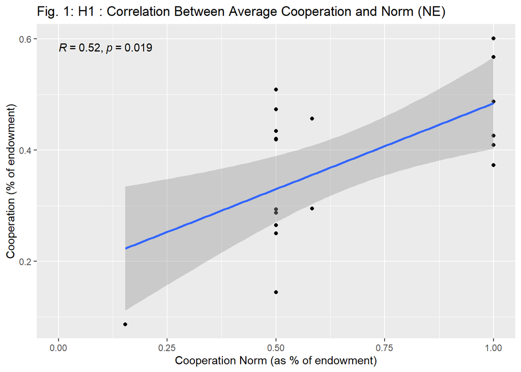

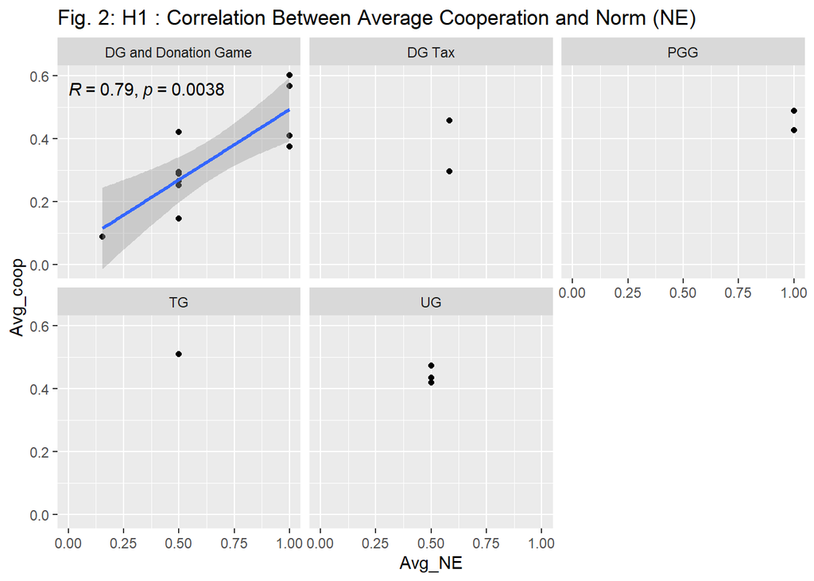

### Results

- Evidence from testing H1 shows that there is a positive and significant correlation between social expectations and cooperative behavior (Fig. 1).
- By splitting data by game type, there is evidence of positive and significant correlation in DG (and Donation game), while norms are not heterogeneous in other game types.
- Hence, the analysis including all games possibly makes more sense here.

## HP2 : Is compliance related to norm strength?

We compute norm strength as:

$$Strength = {NE_{Consistency}+NE_{Specificity}}$$

where:

- $NE_{Specificity} = {1 \over \sigma_{J}}$ is the reciprocal of the standard deviation computed on Krupka-Weber average appropriateness scores across all actions $j$
- $NE_{Consistency} = {1 \over \sigma_{N}}$ is the reciprocal of the standard deviation computed on the most appropriate action $N$.

We compute compliance as $Delta = NE_{avg}-Coop_{avg}$

**Summary of Norm strength**

```
   Min. 1st Qu.  Median    Mean 3rd Qu.    Max.    NA's
  3.208   4.232   6.550   8.542   8.748  42.578       4
```

**Distribution**

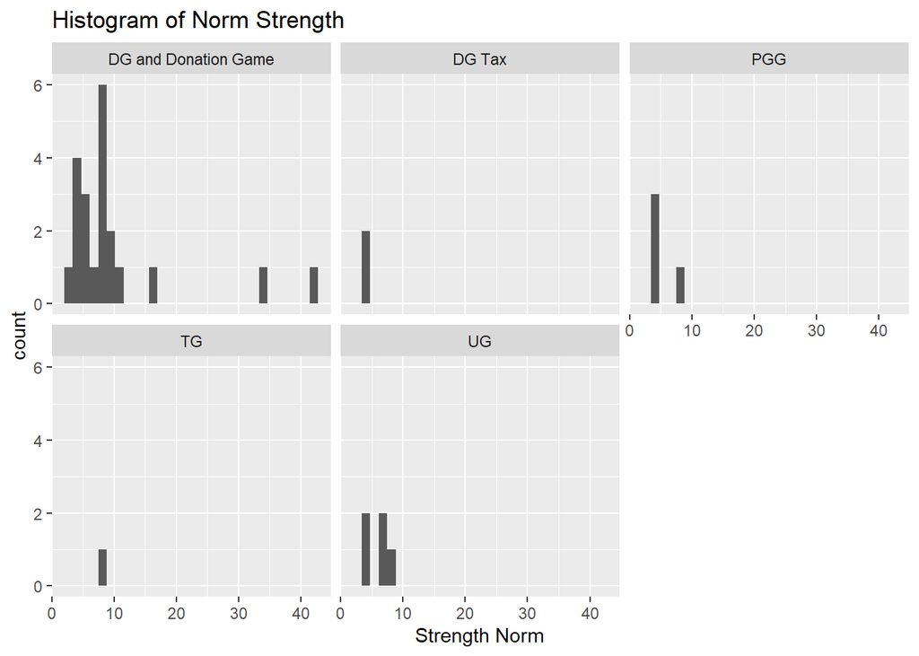

```
    Spearman's rank correlation rho

data:  master$Norm_Strength and master$Delta
S = 1998.3, p-value = 0.02396
alternative hypothesis: true rho is not equal to 0
sample estimates:
       rho
-0.5024446
```

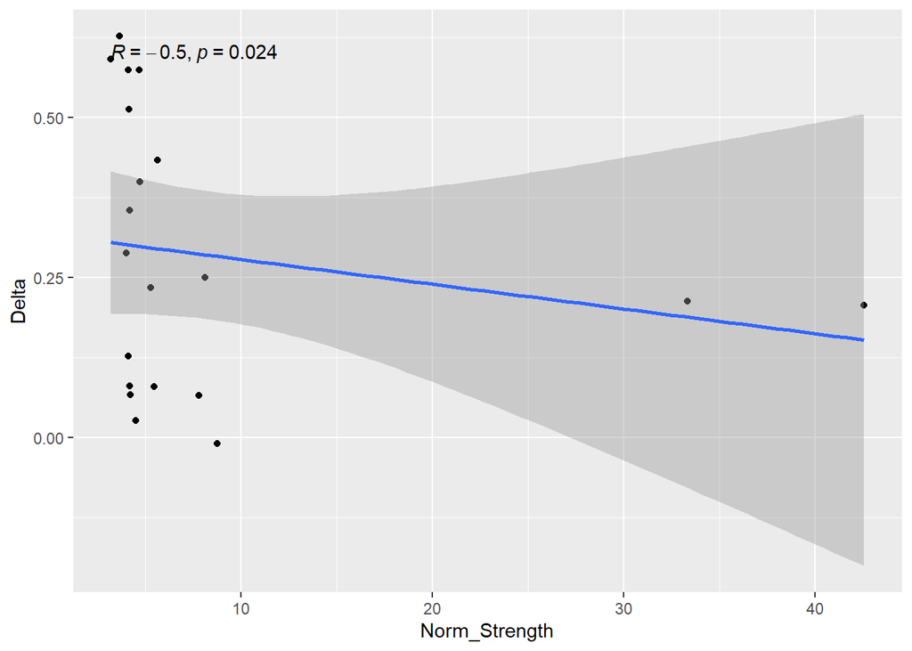

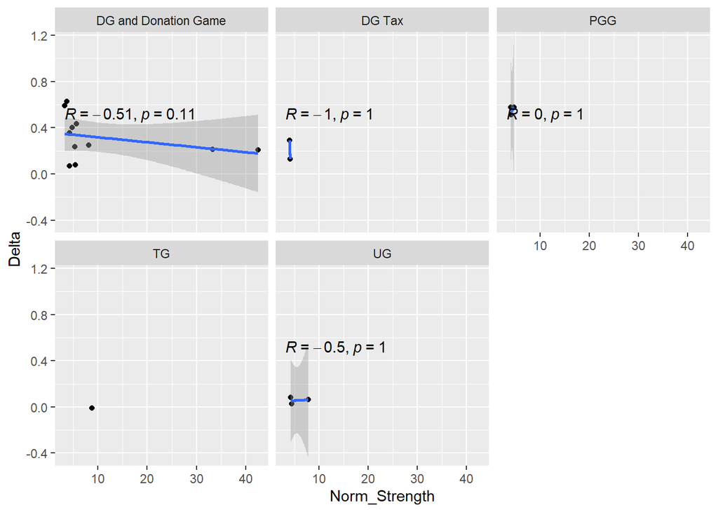

## HP3: Effect of punishment on norms and actions

### Cooperation, Delta and Strength Comparison between DG and UG

Average and Mann-Whitney-Wilcoxon Test

| Macro_game_type | Coop | Avg_Norm | Delta | Strength | n |
| --- | --- | --- | --- | --- | --- |
| DG and Donation Game | 0.3132 | 0.6503 | 0.3140 | 10.9551 | 15 |
| UG | 0.4421 | 0.5000 | 0.0579 | 5.5083 | 3 |
| Difference (Wilcoxon p-value) | 0.0088 | 0.4923 | 0.0242 | 0.1296 |  |

Consistency e Specificity

| Macro_game_type | Specificity | Consistency |
| --- | --- | --- |
| DG and Donation Game | 7.8076 | 2.4050 |
| UG | 2.6635 | 3.3094 |
| Difference (Wilcoxon p-value) | 0.0667 | 0.2571 |

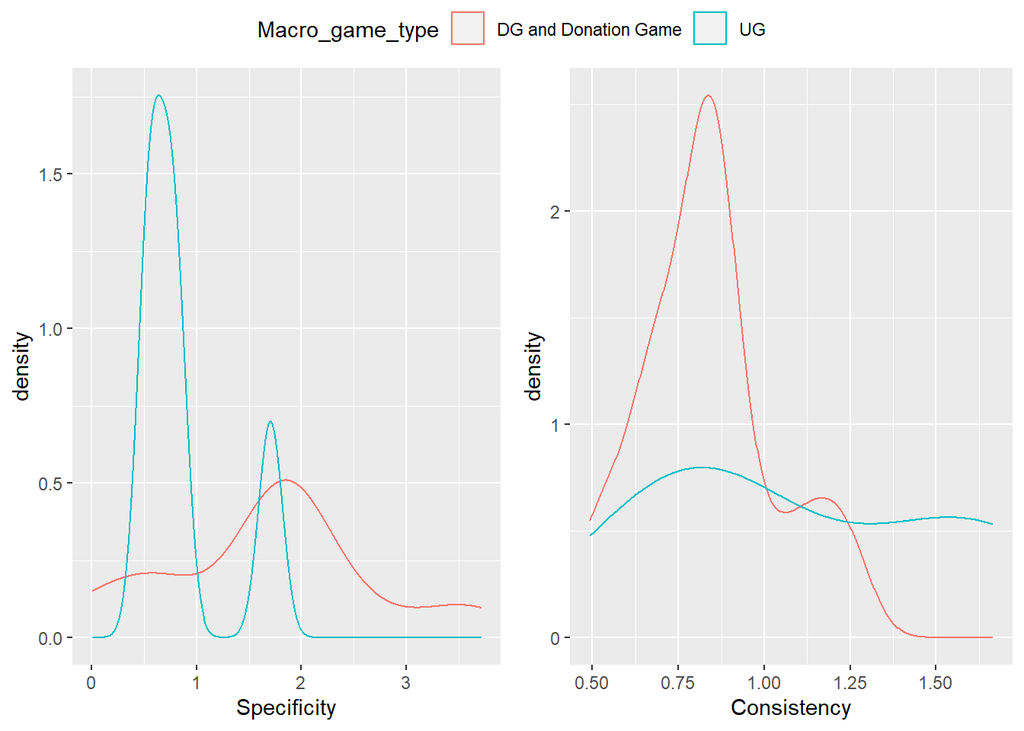

# Individual-level analysis

## Standard Utility framework

Here we estimate a random utility model using a conditional logit model (McFadden 1975). We split our individual-level analysis into 2 steps:

1. *Within subject design belief elicitation*: we estimate the utility function when beliefs and actions are elicited for the same subject
2. *Between subject design belief elicitation*: we estimate the utility function when beliefs and actions are elicited using distinct subjects

For 1., the model we estimate is the following:

$U_{ij} = \alpha \pi_j + \beta S_{ij}$

while for 2., we use $S_j=\Sigma S_{ij}/N$ from the external sample with which social norms were elicited. Hence the model becomes:

$U_{ij} = \alpha \pi_j + \beta S_{j}$

### Within-subjects Design

#### 2020Bas115

DG - Treatment 1 (“Social”)

```
Call:
coxph(formula = Surv(rep(1, 1353L), A) ~ payoff + KW_Normative +
    strata(subject_id), data = Bas115_dg %>% subset.data.frame(subset = treatment_id ==
    "2020Bas115_1a"), method = "exact")

  n= 1353, number of events= 123

                coef exp(coef) se(coef)      z Pr(>|z|)
payoff        0.7632    2.1452   0.1089  7.009  2.4e-12 ***
KW_Normative  3.3497   28.4934   0.3270 10.243  < 2e-16 ***
---
Signif. codes:  0 '***' 0.001 '**' 0.01 '*' 0.05 '.' 0.1 ' ' 1

             exp(coef) exp(-coef) lower .95 upper .95
payoff           2.145     0.4662     1.733     2.656
KW_Normative    28.493     0.0351    15.010    54.089

Concordance= 0.865  (se = 0.021 )
Likelihood ratio test= 232.8  on 2 df,   p=<2e-16
Wald test            = 116  on 2 df,   p=<2e-16
Score (logrank) test = 177.2  on 2 df,   p=<2e-16
```

DG - Treatment 2 (“Private”)

```
Call:
coxph(formula = Surv(rep(1, 1397L), A) ~ payoff + KW_Normative +
    strata(subject_id), data = Bas115_dg %>% subset.data.frame(subset = treatment_id ==
    "2020Bas115_2a"), method = "exact")

  n= 1397, number of events= 127

                coef exp(coef) se(coef)     z Pr(>|z|)
payoff       0.66931   1.95288  0.09349 7.159 8.14e-13 ***
KW_Normative 1.72083   5.58917  0.27691 6.214 5.15e-10 ***
---
Signif. codes:  0 '***' 0.001 '**' 0.01 '*' 0.05 '.' 0.1 ' ' 1

             exp(coef) exp(-coef) lower .95 upper .95
payoff           1.953     0.5121     1.626     2.346
KW_Normative     5.589     0.1789     3.248     9.617

Concordance= 0.769  (se = 0.021 )
Likelihood ratio test= 127.9  on 2 df,   p=<2e-16
Wald test            = 51.42  on 2 df,   p=7e-12
Score (logrank) test = 82.59  on 2 df,   p=<2e-16
```

UG - Treatment 1 (“Social”)

```
Call:
coxph(formula = Surv(rep(1, 660L), A) ~ payoff + KW_Normative +
    strata(subject_id), data = Bas115_ug %>% subset.data.frame(subset = treatment_id ==
    "2020Bas115_1c"), method = "exact")

  n= 660, number of events= 60

                 coef exp(coef) se(coef)      z Pr(>|z|)
payoff       -0.26614   0.76633  0.09456 -2.815  0.00488 **
KW_Normative  2.93745  18.86758  0.39863  7.369 1.72e-13 ***
---
Signif. codes:  0 '***' 0.001 '**' 0.01 '*' 0.05 '.' 0.1 ' ' 1

             exp(coef) exp(-coef) lower .95 upper .95
payoff          0.7663      1.305    0.6367    0.9224
KW_Normative   18.8676      0.053    8.6378   41.2125

Concordance= 0.853  (se = 0.03 )
Likelihood ratio test= 102.7  on 2 df,   p=<2e-16
Wald test            = 54.92  on 2 df,   p=1e-12
Score (logrank) test = 84.05  on 2 df,   p=<2e-16
```

UG - Treatment 2 (“Private”)

```
Call:
coxph(formula = Surv(rep(1, 693L), A) ~ payoff + KW_Normative +
    strata(subject_id), data = Bas115_ug %>% subset.data.frame(subset = treatment_id ==
    "2020Bas115_2c"), method = "exact")

  n= 693, number of events= 63

                 coef exp(coef) se(coef)      z Pr(>|z|)
payoff       -0.10816   0.89749  0.06699 -1.614    0.106
KW_Normative  1.65941   5.25623  0.27210  6.098 1.07e-09 ***
---
Signif. codes:  0 '***' 0.001 '**' 0.01 '*' 0.05 '.' 0.1 ' ' 1

             exp(coef) exp(-coef) lower .95 upper .95
payoff          0.8975     1.1142    0.7871     1.023
KW_Normative    5.2562     0.1903    3.0836     8.960

Concordance= 0.735  (se = 0.039 )
Likelihood ratio test= 52.11  on 2 df,   p=5e-12
Wald test            = 42.27  on 2 df,   p=7e-10
Score (logrank) test = 51.65  on 2 df,   p=6e-12
```

### Between

#### 2016Kim003

For DG game

```
Call:
coxph(formula = Surv(rep(1, 1122L), A) ~ payoff + KW_Normative +
    strata(subject_id), data = Kim003_dg, method = "exact")

  n= 1122, number of events= 66

                  coef exp(coef)  se(coef)     z Pr(>|z|)
payoff       9.162e-01 2.500e+00 1.594e-01 5.749 8.95e-09 ***
KW_Normative 1.373e+01 9.153e+05 2.528e+00 5.430 5.63e-08 ***
---
Signif. codes:  0 '***' 0.001 '**' 0.01 '*' 0.05 '.' 0.1 ' ' 1

             exp(coef) exp(-coef) lower .95 upper .95
payoff             2.5  4.000e-01     1.829 3.416e+00
KW_Normative  915325.9  1.093e-06  6452.852 1.298e+08

Concordance= 0.808  (se = 0.025 )
Likelihood ratio test= 87.71  on 2 df,   p=<2e-16
Wald test            = 33.58  on 2 df,   p=5e-08
Score (logrank) test = 47.36  on 2 df,   p=5e-11
```

For UG game

```
Call:
coxph(formula = Surv(rep(1, 1139L), A) ~ payoff + KW_Normative +
    strata(subject_id), data = Kim003_ug, method = "exact")

  n= 1139, number of events= 67

                  coef exp(coef)  se(coef)     z Pr(>|z|)
payoff       8.984e-01 2.456e+00 1.521e-01 5.907 3.48e-09 ***
KW_Normative 1.823e+01 8.234e+07 2.231e+00 8.168 3.13e-16 ***
---
Signif. codes:  0 '***' 0.001 '**' 0.01 '*' 0.05 '.' 0.1 ' ' 1

             exp(coef) exp(-coef) lower .95 upper .95
payoff       2.456e+00  4.072e-01 1.823e+00 3.309e+00
KW_Normative 8.234e+07  1.215e-08 1.038e+06 6.531e+09

Concordance= 0.888  (se = 0.022 )
Likelihood ratio test= 149.7  on 2 df,   p=<2e-16
Wald test            = 96.49  on 2 df,   p=<2e-16
Score (logrank) test = 134.4  on 2 df,   p=<2e-16
```

#### 2018Her061

```
Call:
coxph(formula = Surv(rep(1, 418L), A) ~ payoff + KW_Normative +
    strata(subject_id), data = Her061, method = "exact")

  n= 418, number of events= 38

                 coef exp(coef) se(coef)     z Pr(>|z|)
payoff         1.8670    6.4689   0.5111 3.653 0.000259 ***
KW_Normative   4.9146  136.2670   1.6665 2.949 0.003187 **
---
Signif. codes:  0 '***' 0.001 '**' 0.01 '*' 0.05 '.' 0.1 ' ' 1

             exp(coef) exp(-coef) lower .95 upper .95
payoff           6.469   0.154586     2.376     17.61
KW_Normative   136.267   0.007339     5.198   3572.03

Concordance= 0.858  (se = 0.035 )
Likelihood ratio test= 67.01  on 2 df,   p=3e-15
Wald test            = 27.24  on 2 df,   p=1e-06
Score (logrank) test = 52.33  on 2 df,   p=4e-12
```

#### 2019Cha026

Treatment 1

```
Call:
coxph(formula = Surv(rep(1, 2497L), A) ~ payoff + KW_Normative +
    strata(subject_id), data = Cha026 %>% subset.data.frame(treatment_id ==
    "2019Cha026_1"), method = "exact")

  n= 2497, number of events= 227

                 coef exp(coef) se(coef)     z Pr(>|z|)
payoff        0.18892   1.20794  0.03229 5.850 4.92e-09 ***
KW_Normative  2.62115  13.75158  0.35966 7.288 3.15e-13 ***
---
Signif. codes:  0 '***' 0.001 '**' 0.01 '*' 0.05 '.' 0.1 ' ' 1

             exp(coef) exp(-coef) lower .95 upper .95
payoff           1.208    0.82786     1.134     1.287
KW_Normative    13.752    0.07272     6.795    27.829

Concordance= 0.848  (se = 0.018 )
Likelihood ratio test= 170.8  on 2 df,   p=<2e-16
Wald test            = 75.61  on 2 df,   p=<2e-16
Score (logrank) test = 124.2  on 2 df,   p=<2e-16
```

Treatment 2

```
Call:
coxph(formula = Surv(rep(1, 4400L), A) ~ payoff + KW_Normative +
    strata(subject_id), data = Cha026 %>% subset.data.frame(treatment_id ==
    "2019Cha026_2"), method = "exact")

  n= 4400, number of events= 400

                coef exp(coef) se(coef)     z Pr(>|z|)
payoff       0.17298   1.18884  0.02238 7.729 1.08e-14 ***
KW_Normative 1.94834   7.01702  0.24428 7.976 1.51e-15 ***
---
Signif. codes:  0 '***' 0.001 '**' 0.01 '*' 0.05 '.' 0.1 ' ' 1

             exp(coef) exp(-coef) lower .95 upper .95
payoff           1.189     0.8412     1.138     1.242
KW_Normative     7.017     0.1425     4.347    11.326

Concordance= 0.791  (se = 0.015 )
Likelihood ratio test= 245.6  on 2 df,   p=<2e-16
Wald test            = 133.4  on 2 df,   p=<2e-16
Score (logrank) test = 189.3  on 2 df,   p=<2e-16
```

### All papers results

Estimated Parameters

| ID | t | game | alpha | beta | SE_alpha | SE_beta | MRS |
| --- | --- | --- | --- | --- | --- | --- | --- |
| 2020Bas115 | 1 | DG | 0.76 | 3.35 | 0.11 | 0.33 | 8.78 |
| 2020Bas115 | 2 | DG | 0.67 | 1.72 | 0.09 | 0.28 | 5.14 |
| 2020Bas115 | 3 | UG | -0.27 | 2.94 | 0.09 | 0.40 | -22.07 |
| 2020Bas115 | 4 | UG | -0.11 | 1.66 | 0.07 | 0.27 | -30.68 |
| 2016Kim003 | 1 | DG | 0.92 | 13.73 | 0.16 | 2.53 | 29.96 |
| 2016Kim003 | 2 | UG | 0.90 | 18.23 | 0.15 | 2.23 | 40.57 |
| 2018Her061 | 1 | DG | 1.87 | 4.91 | 0.51 | 1.67 | 5.26 |
| 2019Cha026 | 1 | DG | 0.19 | 2.62 | 0.03 | 0.36 | 27.75 |
| 2019Cha026 | 2 | DG | 0.17 | 1.95 | 0.02 | 0.24 | 22.53 |

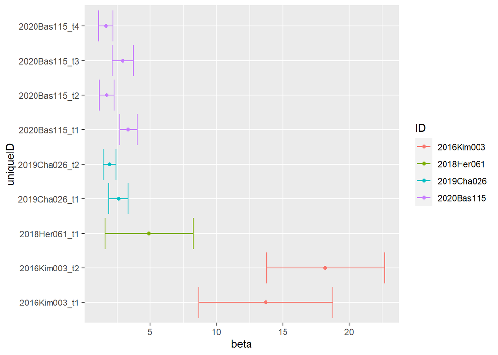

## Augmented Utility framework

Here we augment the standard utility framework by including a measure of norm specificity either at the individual level and at the choice level depending on the nature of the data (between-subject elicitation or within-subject elicitation).

$U_{ij} = \alpha \pi_j + \beta S_{ij} + \eta S_{ij}*\sigma_i(S_{ij})$

where $\sigma(\cdot)$ is the standard deviation of $S_{ij}$ representing uncertainty around the norm.

$U_{ij} = \alpha \pi_j + \beta S_{j} + \eta S_{j}*\sigma_j(S_{ij})$

### Within-subjects elicitation

#### 2020Bas115

DG - T1

```
Call:
coxph(formula = Surv(rep(1, 1353L), A) ~ payoff + KW_Normative +
    KW_Normative:sdi + strata(subject_id), data = Bas115_dg %>%
    subset.data.frame(subset = treatment_id == "2020Bas115_1a"),
    method = "exact")

  n= 1353, number of events= 123

                       coef  exp(coef)   se(coef)      z Pr(>|z|)
payoff            7.480e-01  2.113e+00  1.122e-01  6.669 2.58e-11 ***
KW_Normative      7.031e+00  1.132e+03  1.042e+00  6.749 1.49e-11 ***
KW_Normative:sdi -5.289e+00  5.045e-03  1.360e+00 -3.889 0.000101 ***
---
Signif. codes:  0 '***' 0.001 '**' 0.01 '*' 0.05 '.' 0.1 ' ' 1

                 exp(coef) exp(-coef) lower .95 upper .95
payoff           2.113e+00  4.733e-01 1.696e+00 2.632e+00
KW_Normative     1.132e+03  8.836e-04 1.469e+02 8.721e+03
KW_Normative:sdi 5.045e-03  1.982e+02 3.509e-04 7.253e-02

Concordance= 0.871  (se = 0.022 )
Likelihood ratio test= 247.7  on 3 df,   p=<2e-16
Wald test            = 113.3  on 3 df,   p=<2e-16
Score (logrank) test = 213.8  on 3 df,   p=<2e-16
```

DG - T2

```
Call:
coxph(formula = Surv(rep(1, 1397L), A) ~ payoff + KW_Normative +
    KW_Normative:sdi + strata(subject_id), data = Bas115_dg %>%
    subset.data.frame(subset = treatment_id == "2020Bas115_2a"),
    method = "exact")

  n= 1397, number of events= 127

                       coef  exp(coef)   se(coef)      z Pr(>|z|)
payoff             0.646829   1.909477   0.092258  7.011 2.37e-12 ***
KW_Normative       5.376862 216.342345   1.008117  5.334 9.63e-08 ***
KW_Normative:sdi  -5.494181   0.004111   1.467194 -3.745 0.000181 ***
---
Signif. codes:  0 '***' 0.001 '**' 0.01 '*' 0.05 '.' 0.1 ' ' 1

                 exp(coef) exp(-coef) lower .95 upper .95
payoff           1.909e+00  5.237e-01 1.594e+00 2.288e+00
KW_Normative     2.163e+02  4.622e-03 2.999e+01 1.560e+03
KW_Normative:sdi 4.111e-03  2.433e+02 2.318e-04 7.291e-02

Concordance= 0.802  (se = 0.021 )
Likelihood ratio test= 143.8  on 3 df,   p=<2e-16
Wald test            = 65.53  on 3 df,   p=4e-14
Score (logrank) test = 97.21  on 3 df,   p=<2e-16
```

### Between-subjects elicitation

#### 2016Kim003

DG game

```
Call:
coxph(formula = Surv(rep(1, 1122L), A) ~ payoff + KW_Normative +
    KW_Normative:sdj + strata(subject_id), data = Kim003_dg,
    method = "exact")

  n= 1122, number of events= 66

                      coef exp(coef)  se(coef)     z Pr(>|z|)
payoff           9.162e-01 2.500e+00 1.594e-01 5.749 8.95e-09 ***
KW_Normative     1.373e+01 9.153e+05 2.528e+00 5.430 5.63e-08 ***
KW_Normative:sdj        NA        NA 0.000e+00    NA       NA
---
Signif. codes:  0 '***' 0.001 '**' 0.01 '*' 0.05 '.' 0.1 ' ' 1

                 exp(coef) exp(-coef) lower .95 upper .95
payoff                 2.5  4.000e-01     1.829 3.416e+00
KW_Normative      915325.9  1.093e-06  6452.852 1.298e+08
KW_Normative:sdj        NA         NA        NA        NA

Concordance= 0.808  (se = 0.025 )
Likelihood ratio test= 87.71  on 2 df,   p=<2e-16
Wald test            = 33.58  on 2 df,   p=5e-08
Score (logrank) test = 47.36  on 2 df,   p=5e-11
```

For UG game

```
Call:
coxph(formula = Surv(rep(1, 1139L), A) ~ payoff + KW_Normative +
    KW_Normative * sdj + strata(subject_id), data = Kim003_ug,
    method = "exact")

  n= 1139, number of events= 67

                      coef exp(coef)  se(coef)     z Pr(>|z|)
payoff           8.984e-01 2.456e+00 1.521e-01 5.907 3.48e-09 ***
KW_Normative     1.823e+01 8.234e+07 2.231e+00 8.168 3.13e-16 ***
sdj                     NA        NA 0.000e+00    NA       NA
KW_Normative:sdj        NA        NA 0.000e+00    NA       NA
---
Signif. codes:  0 '***' 0.001 '**' 0.01 '*' 0.05 '.' 0.1 ' ' 1

                 exp(coef) exp(-coef) lower .95 upper .95
payoff           2.456e+00  4.072e-01 1.823e+00 3.309e+00
KW_Normative     8.234e+07  1.215e-08 1.038e+06 6.531e+09
sdj                     NA         NA        NA        NA
KW_Normative:sdj        NA         NA        NA        NA

Concordance= 0.888  (se = 0.022 )
Likelihood ratio test= 149.7  on 2 df,   p=<2e-16
Wald test            = 96.49  on 2 df,   p=<2e-16
Score (logrank) test = 134.4  on 2 df,   p=<2e-16
```

## Individual analysis of norm compliance

### bas155

# Appendix

## Effect of varibility on norms and actions

- 1. Does a higher norm variability lead to lower cooperation?
- 2. Does a higher norm variability lead to higher cooperation variance?

to do so we computed VAR_NE ($NE_{var}$) as:

$$NE_{var} = \sigma^2_{i}(max\{\mu_j(NE)\})$$

#### *a. Does a higher norm variability lead to lower cooperation?*

```
    Spearman's rank correlation rho

data:  master$Var_NE and master$Avg_coop
S = 1361, p-value = 0.9223
alternative hypothesis: true rho is not equal to 0
sample estimates:
        rho
-0.02331704
```

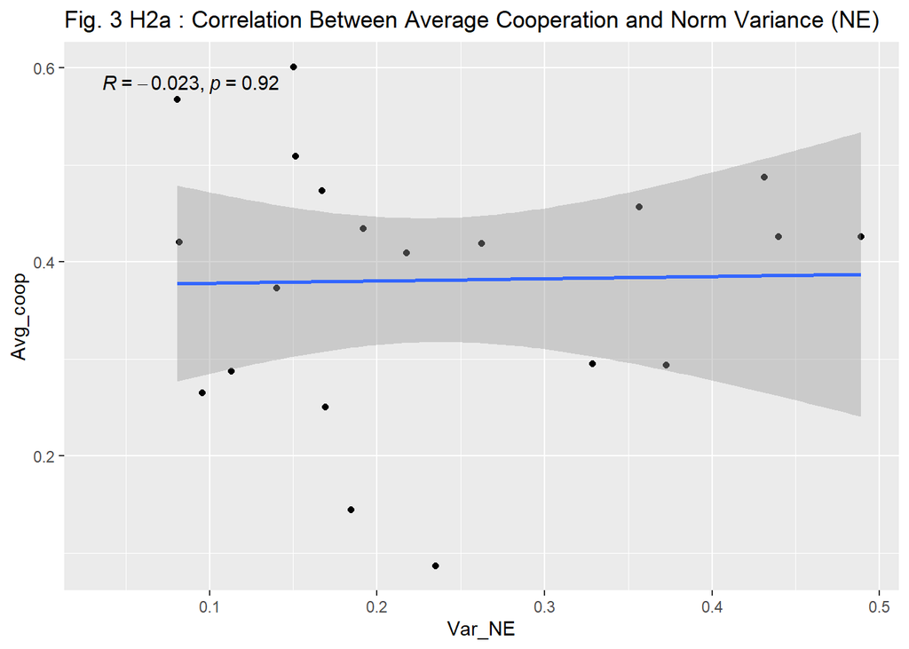

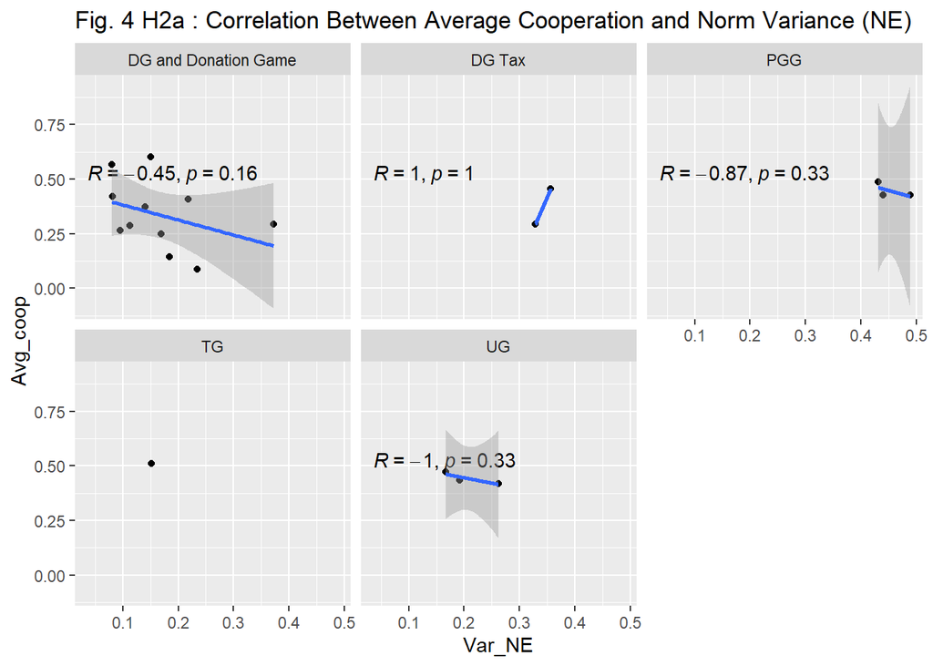

#### *b. Does a higher norm variability lead to higher cooperation var.?*

```
    Spearman's rank correlation rho

data:  master$Var_NE and master$Var_coop
S = 1559.1, p-value = 0.4677
alternative hypothesis: true rho is not equal to 0
sample estimates:
       rho
-0.1722452
```

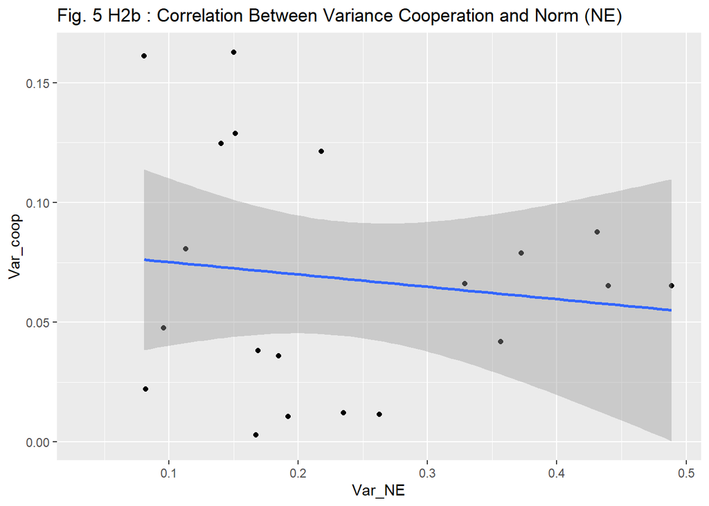

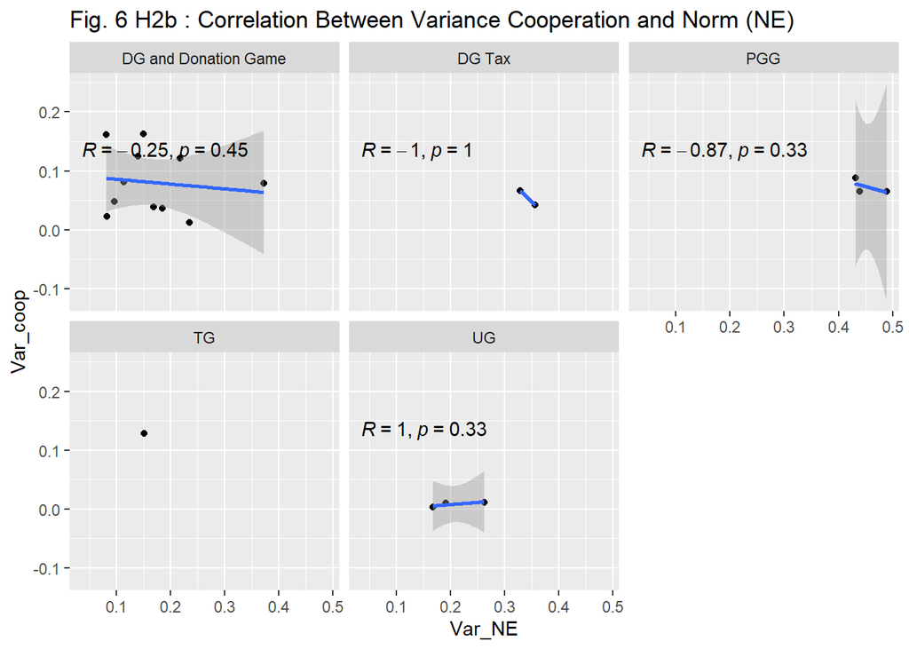

## Papers included

```r
list_of_paper <- master %>% mutate(data_type = ifelse(is.na(Avg_NE), "Actions", ifelse(is.na(Avg_coop), "Norms", "Both"))) %>%
  group_by(data_type, PaperID, Game_type, Method_elicitation, Separate_sample_beliefs, Standard_game) %>%
  summarise(n_treatments = n())
opts <- options(knitr.kable.NA = "")
kbl(list_of_paper, digits = 4, booktabs = T, align = "lcccccc", centering = F, caption = "Ciao") %>%
  kable_styling(position = "left", full_width = F) %>%
  column_spec(1, bold = T)
```

Ciao

| data_type | PaperID | Game_type | Method_elicitation | Separate_sample_beliefs | Standard_game | n_treatments |
| --- | --- | --- | --- | --- | --- | --- |
| Actions | 2017Sen116 | DG | Bicchieri | N | Y | 1 |
| Actions | 2017Sen116 | DG | Both | N | Y | 1 |
| Actions | 2018Kim038 | DG | KW | Y | Y | 2 |
| Both | 2016Kim003 | DG | KW | Y | Y | 1 |
| Both | 2016Kim003 | TG | KW | Y | no check | 1 |
| Both | 2016Kim003 | UG | KW | Y | no check | 1 |
| Both | 2017Tho028 | DG | KW | N | Partially - Limited Actions | 2 |
| Both | 2017Ves049 | PGG | KW | N | no check | 3 |
| Both | 2018Her061 | DG | KW | Y | Y | 1 |
| Both | 2019Cha026 | DG | KW | Y | Partially - Varying endowment betw D R | 2 |
| Both | 2019Dro082 | Donation Game | KW | N | no check | 1 |
| Both | 2020And089 | Donation Game | KW | Y | Y | 2 |
| Both | 2020Bas115 | DG | KW | N | Y | 2 |
| Both | 2020Bas115 | DG Tax | KW | N | Y | 2 |
| Both | 2020Bas115 | UG | KW | N | no check | 2 |
| Norms | 2015Ves034 | UG | KW | N | no check | 2 |
| Norms | 2016Kim003 | PGG | KW | N | no check | 1 |
| Norms | 2019Tjo060 | DG | KW | N | no check | 2 |
| Norms | 2021Kon127 | DG | KW | N | no check | 8 |

```r
datatable(master %>% subset.data.frame(select = c(PaperID, TreatmentCode, Game_type, Avg_coop, SD_NE, Sd_Avg_NE, Norm_Strength, Delta)),rownames = F) %>% formatRound(columns = c("Avg_coop", "Avg_coop", "SD_NE", "Sd_Avg_NE", "Norm_Strength", "Delta"), digits = 2)
```

| PaperID | TreatmentCode | Game_type | Avg_coop | SD_NE | Sd_Avg_NE | Norm_Strength | Delta |
| --- | --- | --- | --- | --- | --- | --- | --- |
| 2021Kon127 | 10 | DG |  | 0.423018752627756 | 0.147154988136432 | 9.15951764806779 |  |
| 2021Kon127 | 9 | DG |  | 0.447115679653279 | 0.167234078733472 | 8.21620013618474 |  |
| 2021Kon127 | 8 | DG |  | 0.420800736778419 | 0.122994843833903 | 10.5068438231499 |  |
| 2021Kon127 | 7 | DG |  | 0.424864901652734 | 0.156388661577107 | 8.7480148212147 |  |
| 2021Kon127 | 4 | DG |  | 0.429093153186764 | 0.07049575265793 | 16.5157480539615 |  |
| 2021Kon127 | 3 | DG |  | 0.505452847832582 | 0.125043858780669 | 9.97561793350188 |  |
| 2021Kon127 | 2 | DG |  | 0.50599823036666 | 0.146211665880905 | 8.8156910341424 |  |
| 2021Kon127 | 1 | DG |  | 0.467073060109354 | 0.180860011878382 | 7.67013087125184 |  |
| 2017Sen116 | 2 | DG | 0.336315789473684 |  |  |  |  |
| 2017Sen116 | 1 | DG | 0.256363636363636 |  |  |  |  |

[output cut: 27 more lines]

## Conditional logit model (Overall model)

```
Call:
coxph(formula = Surv(rep(1, 9627L), A) ~ payoff * paper_id +
    KW_Normative * paper_id + strata(subject_id), data = individual_db_b,
    method = "exact")

  n= 9627, number of events= 798

                                      coef  exp(coef)   se(coef)      z
payoff                           9.637e-01  2.621e+00  1.111e-01  8.670
paper_id2018Her061                      NA         NA  0.000e+00     NA
paper_id2019Cha026                      NA         NA  0.000e+00     NA
KW_Normative                     1.655e+01  1.535e+07  1.693e+00  9.772
payoff:paper_id2018Her061        9.033e-01  2.468e+00  5.230e-01  1.727
payoff:paper_id2019Cha026       -7.868e-01  4.553e-01  1.126e-01 -6.985
paper_id2018Her061:KW_Normative -1.163e+01  8.879e-06  2.376e+00 -4.896
paper_id2019Cha026:KW_Normative -1.437e+01  5.722e-07  1.705e+00 -8.430
                                Pr(>|z|)
payoff                           < 2e-16 ***
paper_id2018Her061                    NA
paper_id2019Cha026                    NA
KW_Normative                     < 2e-16 ***
payoff:paper_id2018Her061         0.0842 .
payoff:paper_id2019Cha026       2.84e-12 ***
paper_id2018Her061:KW_Normative 9.78e-07 ***
paper_id2019Cha026:KW_Normative  < 2e-16 ***
---
Signif. codes:  0 '***' 0.001 '**' 0.01 '*' 0.05 '.' 0.1 ' ' 1

                                exp(coef) exp(-coef) lower .95 upper .95
payoff                          2.621e+00  3.815e-01 2.108e+00 3.259e+00
paper_id2018Her061                     NA         NA        NA        NA
paper_id2019Cha026                     NA         NA        NA        NA
KW_Normative                    1.535e+07  6.516e-08 5.556e+05 4.239e+08
payoff:paper_id2018Her061       2.468e+00  4.052e-01 8.853e-01 6.879e+00
payoff:paper_id2019Cha026       4.553e-01  2.196e+00 3.651e-01 5.678e-01
paper_id2018Her061:KW_Normative 8.879e-06  1.126e+05 8.435e-08 9.345e-04
paper_id2019Cha026:KW_Normative 5.722e-07  1.748e+06 2.024e-08 1.618e-05

Concordance= 0.815  (se = 0.009 )
Likelihood ratio test= 689.1  on 6 df,   p=<2e-16
Wald test            = 344.3  on 6 df,   p=<2e-16
Score (logrank) test = 491.6  on 6 df,   p=<2e-16
```